# Case Study 1 - How Does a Bike-Share Navigate Speedy Success?

Serge Geukjian

9/10/2021

## **ASK**

- BUSINESS TASK: How do annual members and casual riders use Cyclistic bikes differently?
- Key Stakeholders: Lilly Moreno, Marketing & analytics team, and Executive Team

The main goal to reach here is not to add new customers to Cyclistic, but to maximize the annual members since the annual membership is much more profitable to the company and those members will be key for the future growth of the company. So if the main uses for both non-annual and annual members are recognized and studied in dept then the company can focus on how to give a good deal to the non-annual ones and attract them to switch to annual memberships.

## **PREPARE**

**Notes:**

– The data Selected in this study is for the the years 2018 and 2019

– The data was uploaded to SQLite, and a database was created

– Then the data was imported from SQLite to PowerBi for data cleaning and Analysis

- The data is located in spreadsheets, on this [website](https://divvy-tripdata.s3.amazonaws.com/index.html) either each month, quarter, or year alone depending on the size of the data and the year, which ranges from 2013 till 2021 up to date.
- The data is organized in a tabular way containing all the necessary information for the trips of the customers, mentioning the duration of each trip, the start and end locations (stations) and the type of the customer as whether he/she is a one time user or an annual subscriber. Hence the data is organized in a long structure.
- The data is collected directly by the company itself who is issuing the service and the bikes, so the data insures that it’s reliable, and from the data provided it seems that it is ROCCC.
- The provider company has clear and detailed licence and terms to use for the data, so it’s the right thing to acknowledge them and give them full credit with references for the data used.
- Even though there are some changes in the columns of the data over the years the main columns remain consistent and those are the columns that provide the most crucial information like the stops, the type of the user and the duration driven.
- The whole data validation process helps us verify that the data is accurate, safe and consistent, so the analysis can have a proper foundation to be built on, so this will lead the analyst to accurately track the trend and the movement of the rides.
- After some macro-level study of the data we see that it contains some empty (null) values in the “gender” and the “date of birth” columns, also there are some date of births which are very old (in the 1700s-1800s) which are supposed to be removed, so we filtered them out and put the oldest date of birth to be 1919 which is 100 years back from the data being used.

## **PROCESS**

### *SQL*

- SQLite was used here in order to import all the data into a database and then connect that database to PowerBi
- The data was modified in SQL so they all have the same column names, and connected to PowerBi

### *PowerBi*

- Changed all data types of the columns so they are formatted properly. This change is done in the back end M language code of PowerBi and the code looks like this.

```
Table.TransformColumnTypes(#"Removed Duplicates",{{"BIKE_RIDE_ID", Int64.Type}, {"START_DATE", type datetime}, {"END_DATE", type datetime}, {"BIKE_TYPE_ID", Int64.Type}, {"DURATION_sec", Int64.Type}, {"START_STATION_ID", Int64.Type}, {"START_STATION_NAME", type text}, {"END_STATION_ID", Int64.Type},…
```

- After all the columns in all 2018-2019 data have the same column names and data types we appended the tables into one master data table.

```
Table.Combine({#"2018_Q1_Table", #"2018_Q2", #"2018_Q3", #"2018_Q4", #"2019_Q1", #"2019_Q2", #"2019_Q3", #"2019_Q4"})
```

- Checked and removed duplicate data.
- Then created a custom column in our table that shows us the duration in minutes instead of seconds

```
Table.AddColumn(#"Changed Type", "DURATION_min", each [DURATION_sec]/60)
```

This way we can have smaller numbers on our graphs and it will look much more clean and neat. * Filtered out the member birthdays that are before 1919

```
Table.SelectRows(#"Replaced Value1", each [MEMBER_BIRTHDAY] > 1919)
```

- Created a custom table that contains the weekday number and day

```
Table.RenameColumns(#"Changed Type",{{"Column1", "Weekday_num"}, {"Column2", "Weekday"}})
```

- Using the PowerBi Tools we added the starting weekday number to the master data table and connected that to the “Weekday” Table so that in our graphs we can display the name of the weekday instead of only the numbers

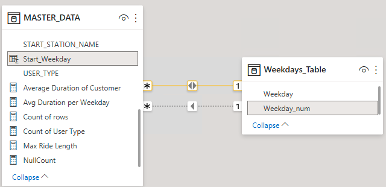

## **Analyze**

```
Avg Duration per Weekday = AVERAGEX(MASTER_DATA,MASTER_DATA[DURATION_min])
Max Ride Length = MAX(MASTER_DATA[DURATION_min])
Count of User Type = COUNTA(MASTER_DATA[USER_TYPE])
```

- The peak period where the duration of rides is the most is during Q3 mostly in July and August where both the subscribers and the one time users use the company’s services more with the subscribers being more than the one time customers. Also on a micro level the average duration of the rides are longer during the weekends but during the weekdays the total duration of the rides are more than the weekends, this means that more people tend to drive during the week for a shorter duration but on the weekends the people who do drive they drive for a longer duration.
- These separations of the graphs and the numbers will help us know when the count and the average riding duration is more for the subscribers and the one time users.

## **Share**

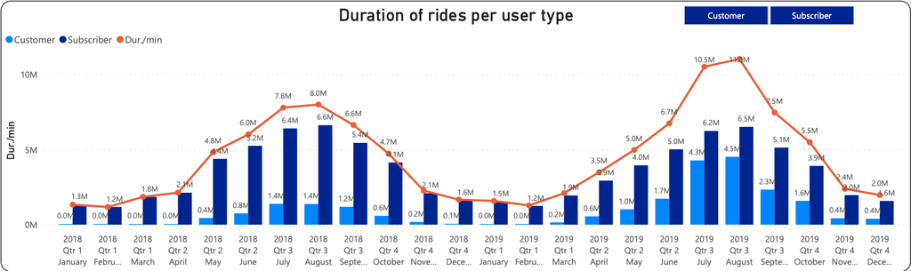

  Here it clearly shows that Summertime, specially during July/August, is when the company has the most users specially subscribers, it also shows that there has been a significant increase in the duration of the customer from 2018 to 2019 with more than double the numbers.
- Next i visualized the average duration ridden over the 2 years throughout the weekdays:

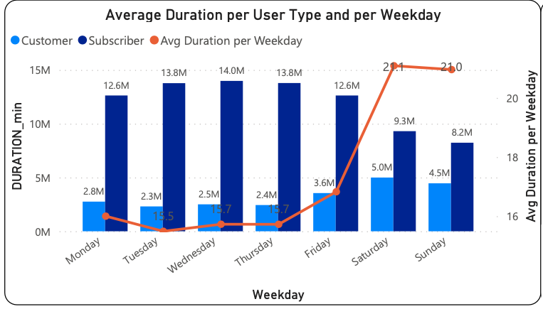

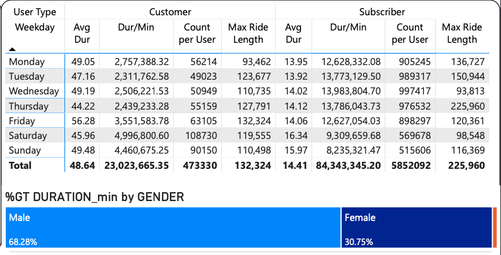

# **Act**

#### *Top 3 recommendations based on analysis*

- Make a new quarterly subscription deal with a very affordable price that is for the lowest duration driven months, from November till February, so this way the duration driven in these months wont decline at a very rapid pace after the summer.
- Introduce a new weekend-only annual subscription with a slightly lower price comparing to the annual subscription, this way people will be encouraged to take either one of the two which will result in more annual users.
- Make a digital wallet campaign where it aims to give credits to users when driven more than a specific duration during the weekdays, and customers can later use these credits to either renew their membership or to gift them to a new user for a one time ride